# Compare ChromHMM Models

Anna L Tyler

October 13, 2020

The purpose of this workflow is to compare different numbers of states specified for ChromHMM. We want to select the model that is best correlated with expression. This workflow can be run after 2.Chromatin_and_Expression.Rmd has been run for multiple state numbers. It uses the “Prop_Expression_Cor” files to find the maximum and minimum associations between proportion of each state and the expression of each transcript. It plots these maxima and minima across the states analyzed.

## Source code

```r
library("here")
all.code.dir <- list.files(here("Code"), full.names = TRUE)
for(i in 1:length(all.code.dir)){
    all.fun <- list.files(all.code.dir[i], full.names = TRUE, pattern = ".R")
    for(j in 1:length(all.fun)){source(all.fun[j])}
}
```

## Collect results

Collect all results for each state. The results are stored in the Prop_Expression_Cor files in each analysis directory. These files hold the r values describing the correlation between the proportion of each state and expression level in inbred mice.

```r
state.num <- list.files(here("Results", "1.ChromHMM"), full.names = TRUE)
state.names <- basename(state.num)
state.as.num <- as.numeric(sapply(strsplit(state.names, "_"), function(x) x[1]))
all.prop <- vector(mode = "list", length = length(state.num))
names(all.prop) <- basename(state.num)
for(i in 1:length(state.num)){
    prop.file <- list.files(path = state.num[i], pattern = "Prop_Expression_Cor", full.names = TRUE)
    if(length(prop.file) > 0){all.prop[[i]] <- readRDS(prop.file)}
}
```

## Compare results

Calculate the median correlations across all states for all models. Plot the maximum and minimum for each model.

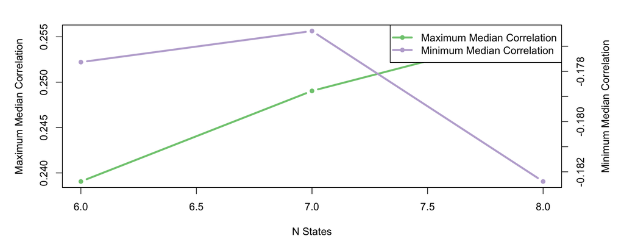

```r
all.prop.r <- lapply(all.prop, function(x) x$all.r)
all.prop.p <- lapply(all.prop, function(x) x$all.p)
med.prop.r <- lapply(all.prop.r, function(x) if(length(x) > 0){apply(x, 2, function(y) median(y, na.rm = TRUE))})

max.med.prop <- lapply(med.prop.r, function(x) if(length(x) > 0){c(min(x), max(x))})
min.prop <- unlist(lapply(max.med.prop, function(x) x[1]))
max.prop <- unlist(lapply(max.med.prop, function(x) x[2]))

min.max.table <- rbind(min.prop, max.prop)

xvals <- as.numeric(sapply(strsplit(names(min.prop), "_"), function(x) x[1]))

plot.two.y.axes(xvals, min.max.table[2,], xvals, min.max.table[1,], lwd = c(3,3), legend.pos = "topright",
xlab = "N States", ylab1 = "Maximum Median Correlation", ylab2 = "Minimum Median Correlation",
plot.type = c("b", "b"), pch = c(16, 16))
```

```r
boxplot.r <- function(r.mats, p.mats, state.num){
    form.states <- paste0(formatC(state.num, digits = 2, flag = 0), "_states_C")
    state.locale <- which(names(r.mats) == form.states)

    r.mat <- r.mats[[state.locale]]
    p.mat <- p.mats[[state.locale]]

    plot.new()
    plot.window(xlim = c(0,(ncol(r.mat)+1)), ylim = c(-1, 1))
    for(i in 1:ncol(r.mat)){
        p.col <- colors.from.values(-log10(p.mat[,i]), use.pheatmap.colors = TRUE)
        not.na <- which(!is.na(r.mat[,i]))
        points(x = jitter(rep(i, nrow(r.mat))), y = r.mat[,i], col = p.col,
        pch = 16, cex = 0.5)
        boxplot(r.mat[not.na,i], at = i, col = "lightgray", add = TRUE)
        }
    axis(2);mtext(side = 2, "Correlation Coefficient", line = 2.5)
    abline(h = 0)
    par(xpd = TRUE)
    text(x = 1:ncol(r.mat), y = -1.1, labels = paste0("State", 1:ncol(r.mat)),
    srt = 90, adj = 1)
    mtext(side = 3, text = paste0(state.num, "-state model"), line = 1)
    par(xpd = FALSE)
}

show.emissions <- function(state.num){
    form.states <- paste0(formatC(state.num, digits = 2, flag = 0), "_states_C")
    emissions.file <- here("Results", "1.ChromHMM", form.states, paste0("emissions_", state.num, ".png"))
    cat("![](",emissions.file,")\n")
}
```

## Correlation Distributions

The following plots show the distributions of correlations between states and gene expression for the states tested.

```r
for(i in 1:length(state.as.num)){
    cat("###", state.names[i], "\n")
    boxplot.r(all.prop.r, all.prop.p,  state.as.num[i])
    #show.emissions(state.as.num[i])
    cat("\n\n")
}
```

### 006_states_C

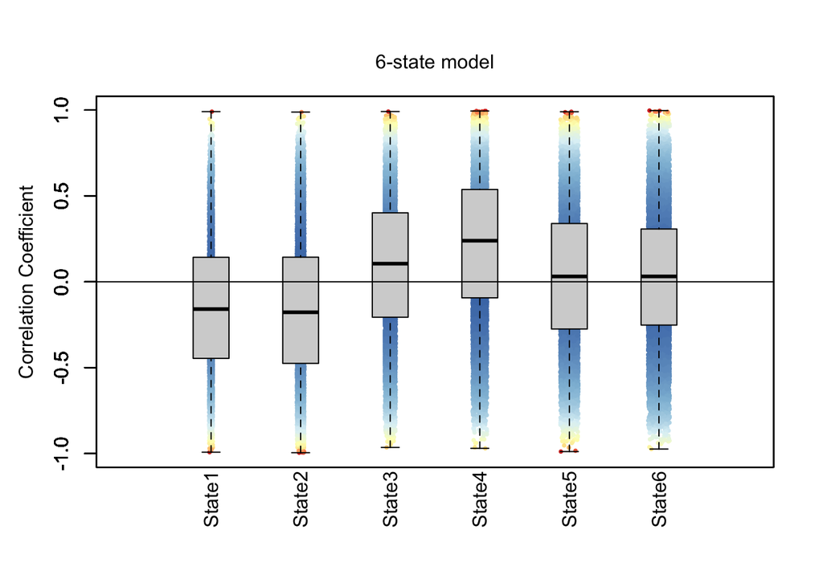

### 007_states_C

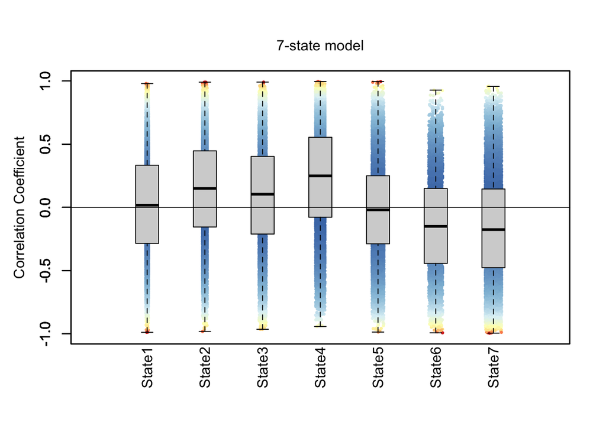

### 008_states_C

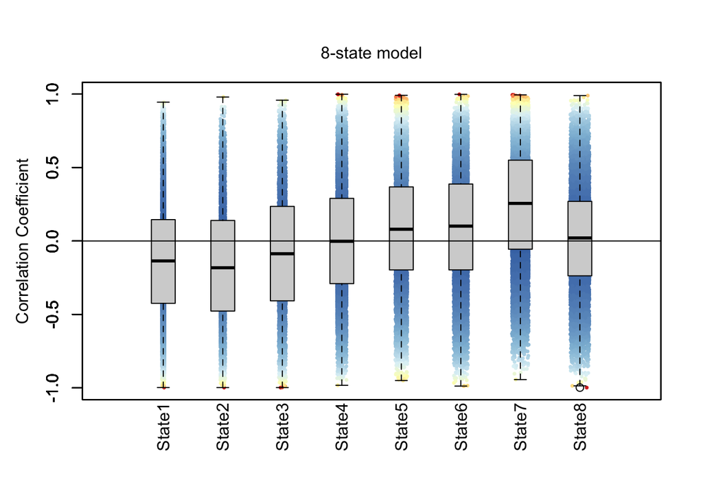